# Factor Model of Asset Return

```python
import sys
!{sys.executable} -m pip install -r requirements.txt
```

```python
import numpy as np
import pandas as pd
import time
import os
import quiz_helper
import matplotlib.pyplot as plt
```

```python
%matplotlib inline
plt.style.use('ggplot')
plt.rcParams['figure.figsize'] = (14, 8)
```

### data bundle

```python
import os
import quiz_helper
from zipline.data import bundles
```

```python
os.environ['ZIPLINE_ROOT'] = os.path.join(os.getcwd(), '..', '..','data','module_4_quizzes_eod')
ingest_func = bundles.csvdir.csvdir_equities(['daily'], quiz_helper.EOD_BUNDLE_NAME)
bundles.register(quiz_helper.EOD_BUNDLE_NAME, ingest_func)
print('Data Registered')
```

```
Data Registered
```

### Build pipeline engine

```python
from zipline.pipeline import Pipeline
from zipline.pipeline.factors import AverageDollarVolume
from zipline.utils.calendars import get_calendar

universe = AverageDollarVolume(window_length=120).top(500)
trading_calendar = get_calendar('NYSE')
bundle_data = bundles.load(quiz_helper.EOD_BUNDLE_NAME)
engine = quiz_helper.build_pipeline_engine(bundle_data, trading_calendar)
```

### View Data¶

With the pipeline engine built, let's get the stocks at the end of the period in the universe we're using. We'll use these tickers to generate the returns data for the our risk model.

```python
universe_end_date = pd.Timestamp('2016-01-05', tz='UTC')

universe_tickers = engine\
    .run_pipeline(
        Pipeline(screen=universe),
        universe_end_date,
        universe_end_date)\
    .index.get_level_values(1)\
    .values.tolist()

universe_tickers
```

```
[Equity(0 [A]),
 Equity(1 [AAL]),
 Equity(2 [AAP]),
 Equity(3 [AAPL]),
 Equity(4 [ABBV]),
 Equity(5 [ABC]),
 Equity(6 [ABT]),
 Equity(7 [ACN]),
 Equity(8 [ADBE]),
 Equity(9 [ADI]),
 Equity(10 [ADM]),
 Equity(11 [ADP]),
 Equity(12 [ADS]),
 Equity(13 [ADSK]),
 Equity(14 [AEE]),
 Equity(15 [AEP]),
 Equity(16 [AES]),
 Equity(17 [AET]),
 Equity(18 [AFL]),
 Equity(19 [AGN]),
 Equity(20 [AIG]),
 Equity(21 [AIV]),
 Equity(22 [AIZ]),
 Equity(23 [AJG]),
 Equity(24 [AKAM]),
 Equity(25 [ALB]),
 Equity(26 [ALGN]),
 Equity(27 [ALK]),
 Equity(28 [ALL]),
 Equity(29 [ALLE]),
 Equity(30 [ALXN]),
 Equity(31 [AMAT]),
 Equity(32 [AMD]),
 Equity(33 [AME]),
 Equity(34 [AMG]),
 Equity(35 [AMGN]),
 Equity(36 [AMP]),
 Equity(37 [AMT]),
 Equity(38 [AMZN]),
 Equity(39 [ANDV]),
```

[output cut: 435 more lines]

```
 Equity(476 [WY]),
 Equity(477 [WYN]),
 Equity(478 [WYNN]),
 Equity(479 [XEC]),
 Equity(480 [XEL]),
 Equity(481 [XL]),
 Equity(482 [XLNX]),
 Equity(483 [XOM]),
 Equity(484 [XRAY]),
 Equity(485 [XRX]),
 Equity(486 [XYL]),
 Equity(487 [YUM]),
 Equity(488 [ZBH]),
 Equity(489 [ZION]),
 Equity(490 [ZTS])]
```

```python
len(universe_tickers)
```

```
490
```

```python
from zipline.data.data_portal import DataPortal

data_portal = DataPortal(
    bundle_data.asset_finder,
    trading_calendar=trading_calendar,
    first_trading_day=bundle_data.equity_daily_bar_reader.first_trading_day,
    equity_minute_reader=None,
    equity_daily_reader=bundle_data.equity_daily_bar_reader,
    adjustment_reader=bundle_data.adjustment_reader)
```

## Get pricing data helper function

```python
from quiz_helper import get_pricing
```

## get pricing data into a dataframe

```python
returns_df = \
    get_pricing(
        data_portal,
        trading_calendar,
        universe_tickers,
        universe_end_date - pd.DateOffset(years=5),
        universe_end_date)\
    .pct_change()[1:].fillna(0) #convert prices into returns

returns_df
```

|  | Equity(0 [A]) | Equity(1 [AAL]) | Equity(2 [AAP]) | Equity(3 [AAPL]) | Equity(4 [ABBV]) | Equity(5 [ABC]) | Equity(6 [ABT]) | Equity(7 [ACN]) | Equity(8 [ADBE]) | Equity(9 [ADI]) | ... | Equity(481 [XL]) | Equity(482 [XLNX]) | Equity(483 [XOM]) | Equity(484 [XRAY]) | Equity(485 [XRX]) | Equity(486 [XYL]) | Equity(487 [YUM]) | Equity(488 [ZBH]) | Equity(489 [ZION]) | Equity(490 [ZTS]) |
| --- | --- | --- | --- | --- | --- | --- | --- | --- | --- | --- | --- | --- | --- | --- | --- | --- | --- | --- | --- | --- | --- |
| 2011-01-07 00:00:00+00:00 | 0.008437 | 0.014230 | 0.026702 | 0.007146 | 0.000000 | 0.001994 | 0.004165 | 0.001648 | -0.007127 | -0.005818 | ... | -0.001838 | -0.005619 | 0.005461 | -0.004044 | -0.013953 | 0.000000 | 0.012457 | -0.000181 | -0.010458 | 0.000000 |
| 2011-01-10 00:00:00+00:00 | -0.004174 | 0.006195 | 0.007435 | 0.018852 | 0.000000 | -0.005714 | -0.008896 | -0.008854 | 0.028714 | 0.002926 | ... | 0.000947 | 0.007814 | -0.006081 | 0.010466 | 0.009733 | 0.000000 | 0.001440 | 0.007784 | -0.017945 | 0.000000 |
| 2011-01-11 00:00:00+00:00 | -0.001886 | -0.043644 | -0.005927 | -0.002367 | 0.000000 | 0.009783 | -0.002067 | 0.013717 | 0.000607 | 0.008753 | ... | 0.001314 | 0.010179 | 0.007442 | 0.007351 | 0.006116 | 0.000000 | -0.006470 | 0.035676 | 0.007467 | 0.000000 |
| 2011-01-12 00:00:00+00:00 | 0.017254 | -0.008237 | 0.013387 | 0.008133 | 0.000000 | -0.005979 | -0.001011 | 0.022969 | 0.017950 | 0.000257 | ... | 0.004986 | 0.015666 | 0.011763 | 0.027182 | 0.004386 | 0.000000 | 0.002631 | 0.014741 | -0.011903 | 0.000000 |
| 2011-01-13 00:00:00+00:00 | -0.004559 | 0.000955 | 0.003031 | 0.003657 | 0.000000 | 0.014925 | -0.004451 | -0.000400 | -0.005719 | -0.005012 | ... | 0.030499 | -0.003217 | 0.001694 | 0.000547 | -0.018235 | 0.000000 | -0.005084 | -0.004665 | -0.009178 | 0.000000 |
| 2011-01-14 00:00:00+00:00 | 0.003439 | -0.009156 | 0.003022 | 0.008106 | 0.000000 | 0.001395 | -0.010111 | 0.002590 | 0.012283 | 0.019827 | ... | 0.026607 | 0.025894 | 0.014743 | -0.000287 | 0.026494 | 0.000000 | -0.021661 | 0.005949 | 0.033177 | 0.000000 |
| 2011-01-18 00:00:00+00:00 | 0.034254 | -0.062085 | -0.004286 | -0.022474 | 0.000000 | 0.020889 | 0.006621 | 0.006998 | 0.011542 | 0.032645 | ... | 0.001678 | 0.002501 | 0.011163 | 0.011589 | 0.006044 | 0.000000 | 0.029453 | 0.006998 | -0.008534 | 0.000000 |
| 2011-01-19 00:00:00+00:00 | -0.010224 | -0.008929 | 0.008754 | -0.005314 | 0.000000 | -0.017144 | 0.002753 | -0.002962 | -0.007899 | -0.020575 | ... | -0.014834 | -0.023590 | -0.005968 | -0.019899 | -0.012847 | 0.000000 | 0.000818 | -0.004098 | -0.018433 | 0.000000 |
| 2011-01-20 00:00:00+00:00 | -0.008496 | 0.021953 | -0.004732 | -0.018189 | 0.000000 | 0.004794 | 0.013322 | 0.018713 | -0.012386 | -0.002818 | ... | -0.024512 | 0.007744 | -0.006261 | -0.000841 | -0.033798 | 0.000000 | -0.013182 | -0.001612 | -0.007972 | 0.000000 |
| 2011-01-21 00:00:00+00:00 | 0.007873 | -0.041038 | 0.005544 | -0.017911 | 0.000000 | 0.010642 | -0.000853 | -0.001952 | -0.006569 | -0.004113 | ... | 0.000000 | 0.000615 | 0.015825 | -0.003048 | -0.000872 | 0.000000 | -0.007590 | 0.009325 | 0.024020 | 0.000000 |
| 2011-01-24 00:00:00+00:00 | 0.014646 | 0.027473 | -0.001106 | 0.032837 | 0.000000 | 0.005249 | 0.005223 | 0.008420 | 0.022843 | 0.014974 | ... | 0.012359 | 0.016011 | -0.004943 | 0.001660 | 0.008049 | 0.000000 | 0.000601 | -0.016501 | -0.023021 | 0.000000 |
| 2011-01-25 00:00:00+00:00 | -0.006736 | 0.002982 | 0.009146 | 0.011710 | 0.000000 | -0.009363 | -0.004347 | 0.004859 | -0.013811 | -0.014505 | ... | 0.002178 | 0.006273 | 0.001154 | 0.001134 | 0.015143 | 0.000000 | -0.006208 | 0.017142 | -0.008836 | 0.000000 |
| 2011-01-26 00:00:00+00:00 | -0.030736 | 0.066133 | 0.003593 | 0.007193 | 0.000000 | 0.012227 | -0.025241 | 0.012192 | -0.001192 | 0.002837 | ... | 0.002628 | 0.005934 | 0.012453 | 0.000552 | -0.076291 | 0.000000 | -0.004803 | -0.019524 | -0.010626 | 0.000000 |
| 2011-01-27 00:00:00+00:00 | 0.007721 | 0.023178 | -0.001553 | -0.001877 | 0.000000 | 0.011833 | -0.007928 | 0.000179 | 0.009845 | 0.007480 | ... | 0.014267 | 0.021169 | 0.002751 | 0.016396 | 0.024664 | 0.000000 | -0.003746 | 0.068754 | 0.020160 | 0.000000 |
| 2011-01-28 00:00:00+00:00 | -0.018846 | -0.080553 | -0.000936 | -0.020710 | 0.000000 | -0.022262 | -0.019200 | -0.016035 | -0.040177 | -0.022460 | ... | -0.025647 | -0.020108 | -0.011131 | -0.021871 | -0.022229 | 0.000000 | -0.025001 | -0.008472 | -0.013873 | 0.000000 |
| 2011-01-31 00:00:00+00:00 | 0.003608 | -0.023615 | -0.002351 | 0.009578 | 0.000000 | -0.003893 | -0.007248 | -0.000980 | 0.017236 | 0.013818 | ... | 0.004846 | 0.000298 | 0.021396 | -0.007560 | 0.006615 | 0.000000 | 0.007748 | 0.009902 | 0.006378 | 0.000000 |
| 2011-02-01 00:00:00+00:00 | 0.011654 | -0.001047 | -0.009218 | 0.016818 | 0.000000 | 0.011976 | 0.001546 | 0.017498 | 0.013918 | 0.021624 | ... | 0.015687 | 0.032003 | 0.040037 | 0.024795 | 0.024498 | 0.000000 | 0.014102 | 0.017746 | 0.030970 | 0.000000 |
| 2011-02-02 00:00:00+00:00 | 0.010112 | -0.039304 | -0.027477 | -0.002053 | 0.000000 | -0.021197 | 0.011068 | 0.003632 | -0.002387 | 0.002280 | ... | -0.012846 | -0.004518 | -0.005958 | -0.010390 | -0.001827 | 0.000000 | 0.006562 | 0.005161 | -0.003706 | 0.000000 |
| 2011-02-03 00:00:00+00:00 | -0.000289 | 0.007310 | 0.014126 | -0.002560 | 0.000000 | -0.003662 | 0.005894 | 0.004178 | 0.002991 | -0.013341 | ... | 0.010430 | -0.008169 | 0.000347 | 0.008556 | 0.004596 | 0.000000 | 0.031413 | -0.000333 | -0.000394 | 0.000000 |
| 2011-02-04 00:00:00+00:00 | 0.005627 | -0.036500 | 0.024014 | 0.008915 | 0.000000 | 0.033047 | 0.002616 | -0.004360 | -0.005070 | 0.019659 | ... | 0.009471 | 0.024709 | -0.001917 | 0.003048 | -0.005506 | 0.000000 | 0.001408 | 0.002471 | 0.016111 | 0.000000 |
| 2011-02-07 00:00:00+00:00 | 0.007709 | 0.052046 | 0.008114 | 0.015538 | 0.000000 | -0.002178 | -0.009341 | 0.002279 | 0.005995 | -0.003514 | ... | 0.006801 | -0.005073 | 0.007803 | 0.006852 | 0.002768 | 0.000000 | 0.002028 | -0.010876 | 0.027617 | 0.000000 |
| 2011-02-08 00:00:00+00:00 | 0.010854 | 0.016455 | 0.006202 | 0.009440 | 0.000000 | 0.002182 | -0.001738 | -0.000557 | 0.000298 | -0.006010 | ... | 0.003846 | 0.001795 | -0.006077 | 0.005182 | -0.002761 | 0.000000 | 0.003851 | -0.000495 | 0.004780 | 0.000000 |
| 2011-02-09 00:00:00+00:00 | 0.004664 | 0.000000 | 0.016955 | 0.008332 | 0.000000 | 0.003006 | -0.001530 | 0.001138 | -0.016682 | 0.004781 | ... | -0.011837 | -0.001792 | -0.005178 | -0.018441 | 0.003705 | 0.000000 | -0.001821 | -0.009851 | -0.004757 | 0.000000 |
| 2011-02-10 00:00:00+00:00 | 0.000413 | -0.003048 | -0.011367 | -0.010109 | 0.000000 | 0.001101 | -0.001110 | 0.005503 | 0.016965 | 0.004513 | ... | -0.008947 | 0.003914 | 0.007876 | 0.005512 | -0.004624 | 0.000000 | 0.004853 | 0.011449 | -0.026498 | 0.000000 |
| 2011-02-11 00:00:00+00:00 | -0.007150 | 0.028364 | 0.000764 | 0.006505 | 0.000000 | -0.001375 | 0.001534 | -0.011146 | 0.002979 | 0.015007 | ... | 0.001705 | 0.010765 | -0.004562 | 0.007147 | 0.012021 | 0.000000 | 0.000616 | 0.009660 | 0.014256 | 0.000000 |
| 2011-02-14 00:00:00+00:00 | 0.001663 | -0.015790 | -0.023274 | 0.006529 | 0.000000 | 0.005750 | 0.009245 | 0.000202 | 0.005643 | 0.009877 | ... | -0.011616 | 0.000318 | 0.025230 | -0.005443 | 0.005476 | 0.000000 | 0.010657 | 0.002484 | -0.010021 | 0.000000 |
| 2011-02-15 00:00:00+00:00 | -0.011905 | 0.011043 | -0.003926 | 0.002016 | 0.000000 | -0.007329 | 0.016750 | -0.008021 | 0.002363 | 0.000239 | ... | -0.006079 | -0.001804 | -0.022853 | 0.004097 | 0.003604 | 0.000000 | 0.008526 | -0.001815 | -0.004461 | 0.000000 |
| 2011-02-16 00:00:00+00:00 | 0.015123 | 0.001958 | 0.013860 | 0.008967 | 0.000000 | -0.003554 | -0.010502 | 0.027329 | 0.022098 | -0.003905 | ... | 0.009174 | 0.003863 | 0.008682 | 0.000285 | 0.027093 | 0.000000 | 0.008898 | 0.010557 | 0.001206 | 0.000000 |
| 2011-02-17 00:00:00+00:00 | -0.003311 | -0.017791 | -0.024844 | -0.013309 | 0.000000 | 0.029148 | 0.001301 | 0.011784 | 0.008360 | 0.008559 | ... | 0.015656 | 0.000318 | 0.002275 | -0.001911 | 0.000000 | 0.000000 | 0.003906 | 0.015325 | -0.003227 | 0.000000 |
| 2011-02-18 00:00:00+00:00 | 0.011078 | -0.020103 | -0.006693 | -0.021595 | 0.000000 | 0.009620 | 0.012106 | -0.007953 | 0.011721 | -0.001691 | ... | 0.053404 | 0.001447 | 0.007393 | 0.013148 | -0.004390 | 0.000000 | -0.004110 | 0.023782 | -0.017960 | 0.000000 |
| ... | ... | ... | ... | ... | ... | ... | ... | ... | ... | ... | ... | ... | ... | ... | ... | ... | ... | ... | ... | ... | ... |
| 2015-11-20 00:00:00+00:00 | 0.001072 | -0.002373 | 0.002767 | 0.004381 | 0.009256 | -0.000905 | 0.006113 | 0.006430 | 0.000545 | -0.005843 | ... | 0.008131 | 0.000412 | -0.006352 | 0.002793 | 0.002899 | -0.004498 | 0.015060 | -0.003176 | 0.000000 | 0.008950 |
| 2015-11-23 00:00:00+00:00 | -0.007094 | 0.002379 | -0.001228 | -0.012989 | 0.000646 | -0.003728 | -0.012381 | -0.001206 | 0.001634 | -0.044107 | ... | -0.004696 | -0.006955 | 0.006131 | 0.007345 | 0.027692 | 0.001322 | -0.000966 | -0.008581 | -0.001992 | -0.007600 |
| 2015-11-24 00:00:00+00:00 | 0.002085 | -0.025309 | 0.003504 | 0.009594 | -0.000323 | -0.002336 | 0.000210 | -0.004537 | 0.000435 | 0.063741 | ... | -0.000777 | 0.012960 | 0.019935 | -0.009563 | -0.012992 | -0.001871 | -0.004252 | -0.009043 | 0.002650 | -0.000651 |
| 2015-11-25 00:00:00+00:00 | -0.008206 | 0.001938 | 0.006805 | -0.007151 | -0.013744 | 0.004365 | -0.000862 | -0.002338 | -0.002500 | -0.002810 | ... | -0.008888 | -0.004458 | -0.007690 | -0.002792 | -0.001913 | 0.004824 | 0.002894 | -0.006174 | -0.000309 | 0.000868 |
| 2015-11-27 00:00:00+00:00 | -0.003256 | 0.009201 | 0.003285 | -0.001863 | -0.004803 | 0.000612 | 0.000210 | 0.003363 | 0.004359 | 0.003315 | ... | 0.004736 | 0.004478 | -0.000257 | 0.002633 | 0.003795 | -0.002140 | 0.005105 | -0.002869 | 0.005013 | 0.002343 |
| 2015-11-30 00:00:00+00:00 | -0.010209 | -0.010321 | -0.012798 | 0.004159 | -0.030838 | -0.003542 | -0.011004 | -0.002228 | -0.007703 | 0.019522 | ... | 0.004212 | 0.009348 | 0.005294 | -0.007363 | -0.007524 | -0.006928 | -0.006183 | 0.000101 | -0.004339 | -0.008071 |
| 2015-12-01 00:00:00+00:00 | 0.015748 | 0.048493 | -0.002396 | -0.008116 | 0.014957 | 0.008718 | 0.012022 | 0.008480 | 0.011918 | -0.000970 | ... | 0.015192 | 0.011075 | 0.002821 | 0.021600 | 0.013276 | 0.008582 | 0.027170 | 0.016927 | 0.015028 | 0.006632 |
| 2015-12-02 00:00:00+00:00 | -0.005284 | 0.012930 | -0.027166 | -0.009030 | -0.022022 | -0.006534 | -0.005287 | -0.004991 | -0.005727 | -0.006990 | ... | -0.003858 | -0.024693 | -0.028571 | 0.007572 | -0.029962 | -0.018335 | 0.006313 | -0.004473 | -0.015448 | -0.013610 |
| 2015-12-03 00:00:00+00:00 | -0.009521 | -0.012555 | -0.019944 | -0.009292 | -0.027724 | -0.001415 | -0.023650 | -0.015429 | -0.022930 | -0.027826 | ... | -0.008294 | -0.010820 | -0.014327 | 0.002733 | -0.000959 | -0.005676 | -0.024272 | -0.028367 | -0.015725 | -0.025244 |
| 2015-12-04 00:00:00+00:00 | 0.020199 | 0.039303 | 0.006779 | 0.033246 | 0.018899 | 0.011957 | 0.026046 | 0.029924 | 0.029696 | 0.002713 | ... | 0.022211 | 0.010326 | 0.005736 | 0.007495 | 0.011599 | 0.024774 | 0.041159 | 0.011977 | 0.024452 | 0.027882 |
| 2015-12-07 00:00:00+00:00 | -0.000340 | 0.018020 | -0.029578 | -0.006298 | -0.015921 | 0.000898 | 0.005727 | -0.001463 | -0.032188 | -0.011988 | ... | 0.000000 | -0.008791 | -0.026122 | -0.001900 | -0.029576 | -0.019647 | 0.003540 | -0.001384 | -0.042085 | -0.011841 |
| 2015-12-08 00:00:00+00:00 | -0.023307 | -0.026876 | -0.008866 | -0.000425 | 0.007114 | 0.004906 | -0.000209 | -0.000280 | 0.023661 | -0.008216 | ... | -0.004606 | -0.003910 | -0.028251 | -0.012067 | -0.004930 | -0.017074 | -0.010735 | -0.006277 | -0.031813 | 0.000666 |
| 2015-12-09 00:00:00+00:00 | -0.005170 | -0.020213 | 0.022223 | -0.022077 | -0.011303 | 0.001984 | -0.012948 | -0.014876 | -0.023550 | -0.023608 | ... | -0.013092 | -0.009934 | 0.013390 | -0.021066 | -0.009869 | -0.000570 | -0.023679 | 0.002205 | -0.007490 | -0.015900 |
| 2015-12-10 00:00:00+00:00 | 0.015039 | 0.010092 | -0.009466 | 0.004763 | -0.004463 | 0.012720 | 0.007772 | 0.002897 | -0.006699 | 0.008821 | ... | -0.006757 | 0.001883 | 0.000798 | -0.000317 | 0.014970 | 0.012138 | -0.008256 | -0.000297 | 0.014759 | 0.019695 |
| 2015-12-11 00:00:00+00:00 | -0.012227 | -0.045356 | -0.019179 | -0.025740 | -0.031185 | 0.001280 | -0.020962 | -0.021380 | 0.027653 | -0.003843 | ... | -0.014938 | -0.012713 | -0.017840 | -0.017755 | -0.012793 | -0.013062 | -0.025836 | -0.010112 | -0.029782 | -0.005856 |
| 2015-12-14 00:00:00+00:00 | -0.011197 | -0.007618 | -0.008325 | -0.006189 | 0.025898 | 0.004406 | 0.010145 | 0.010071 | 0.020127 | -0.001938 | ... | 0.007216 | -0.000941 | 0.022738 | -0.001835 | -0.017913 | 0.011580 | 0.004910 | 0.005356 | -0.014991 | 0.016583 |
| 2015-12-15 00:00:00+00:00 | 0.024683 | 0.019768 | 0.057990 | -0.017686 | 0.017133 | -0.008194 | 0.017415 | 0.003386 | 0.008149 | -0.004743 | ... | 0.015392 | 0.013516 | 0.044710 | 0.004357 | 0.016222 | 0.001635 | 0.013410 | 0.015787 | 0.035626 | 0.008156 |
| 2015-12-16 00:00:00+00:00 | 0.010780 | 0.014190 | 0.029771 | 0.007685 | 0.021998 | -0.000985 | 0.010080 | 0.022107 | 0.016379 | 0.017336 | ... | 0.004713 | 0.000531 | -0.003522 | 0.008507 | 0.024937 | 0.020719 | 0.012809 | 0.008606 | 0.010755 | 0.002538 |
| 2015-12-17 00:00:00+00:00 | -0.017212 | -0.017122 | -0.048190 | -0.021196 | -0.021696 | 0.007386 | -0.017153 | -0.053355 | -0.014232 | -0.024510 | ... | -0.001564 | -0.018147 | -0.015037 | -0.003142 | -0.007787 | -0.026697 | -0.018224 | -0.011966 | -0.015960 | -0.007637 |
| 2015-12-18 00:00:00+00:00 | -0.041084 | -0.032259 | -0.022863 | -0.027064 | -0.011342 | -0.004497 | -0.034461 | -0.012883 | -0.030679 | -0.016940 | ... | -0.019013 | -0.012314 | -0.008724 | -0.010451 | -0.003944 | -0.017002 | -0.004991 | -0.017384 | -0.037845 | -0.002791 |
| 2015-12-21 00:00:00+00:00 | 0.009455 | 0.031863 | 0.000531 | 0.012254 | 0.008245 | 0.009916 | 0.007778 | 0.010404 | 0.003395 | 0.011962 | ... | 0.006358 | 0.016776 | -0.000255 | 0.007035 | 0.014779 | 0.008360 | 0.021714 | 0.012842 | 0.002271 | 0.015894 |
| 2015-12-22 00:00:00+00:00 | 0.010502 | 0.011670 | -0.011760 | -0.000927 | 0.024746 | 0.002617 | 0.009978 | 0.007473 | 0.024012 | 0.003326 | ... | 0.031671 | 0.002735 | 0.005054 | 0.010047 | 0.038863 | 0.009977 | -0.005448 | 0.014966 | 0.014553 | 0.008027 |
| 2015-12-23 00:00:00+00:00 | 0.011803 | 0.009219 | 0.008325 | 0.012869 | 0.017178 | 0.007567 | 0.013950 | 0.006365 | 0.009380 | 0.008296 | ... | 0.009199 | 0.009501 | 0.032702 | 0.007586 | 0.011193 | 0.017237 | 0.015349 | 0.010219 | 0.018773 | 0.005444 |
| 2015-12-24 00:00:00+00:00 | -0.003682 | 0.012022 | 0.000465 | -0.005341 | -0.002041 | 0.000090 | 0.000000 | -0.001820 | -0.004224 | 0.005673 | ... | 0.009623 | -0.000620 | -0.010724 | -0.002127 | 0.005553 | -0.001614 | -0.001620 | 0.001364 | 0.003975 | 0.003121 |
| 2015-12-28 00:00:00+00:00 | 0.007040 | -0.013259 | 0.009526 | -0.011204 | 0.004953 | 0.002309 | -0.001550 | -0.001441 | -0.001060 | -0.006164 | ... | 0.000503 | -0.001064 | -0.007439 | 0.004930 | -0.021138 | -0.003484 | -0.002177 | -0.006413 | -0.005033 | -0.004784 |
| 2015-12-29 00:00:00+00:00 | 0.019443 | 0.006256 | 0.010957 | 0.017976 | 0.011911 | 0.005569 | 0.017542 | 0.011914 | 0.011996 | 0.015224 | ... | 0.013813 | 0.007964 | 0.005336 | 0.011436 | 0.011283 | 0.004307 | 0.005415 | 0.007235 | 0.006174 | 0.008997 |
| 2015-12-30 00:00:00+00:00 | -0.006384 | -0.016085 | -0.005254 | -0.013056 | 0.005904 | 0.002391 | -0.012017 | 0.005124 | -0.000524 | -0.013256 | ... | -0.014617 | -0.007064 | -0.013261 | -0.008079 | 0.001847 | -0.006182 | -0.005781 | -0.002921 | -0.012235 | -0.001454 |
| 2015-12-31 00:00:00+00:00 | -0.012432 | -0.010532 | -0.005879 | -0.019199 | -0.009372 | -0.012481 | -0.007953 | -0.012844 | -0.014064 | -0.021745 | ... | -0.016052 | -0.018175 | -0.002050 | -0.009119 | -0.008371 | -0.010031 | -0.010299 | 0.001176 | -0.006212 | -0.007051 |
| 2016-01-04 00:00:00+00:00 | -0.028282 | -0.033988 | 0.011494 | 0.000855 | -0.027512 | -0.017741 | -0.044067 | -0.025551 | -0.020971 | -0.015919 | ... | -0.024767 | -0.024922 | -0.006276 | -0.032711 | -0.031051 | -0.011520 | -0.011489 | -0.007604 | -0.021614 | -0.013564 |
| 2016-01-05 00:00:00+00:00 | 0.004058 | -0.009541 | -0.006830 | -0.025054 | -0.004169 | 0.014629 | -0.000247 | 0.005207 | 0.004023 | -0.007347 | ... | 0.002098 | 0.014863 | 0.008511 | 0.020390 | -0.001957 | -0.000286 | -0.002495 | 0.020820 | -0.010853 | 0.015647 |

1256 rows × 490 columns

## Let's look at one stock

Let's look at this for just one stock. We'll pick AAPL in this example.

```python
aapl_col = returns_df.columns[3]
asset_return = returns_df[aapl_col]

asset_return = asset_return.rename('asset_return')
```

## Factor returns

Let's make up a "factor" by taking an average of all stocks in our list. You can think of this as an equal weighted index of the 490 stocks, kind of like a measure of the "market". We'll also make another factor by calculating the median of all the stocks. These are mainly intended to help us generate some data to work with. We'll go into how some common risk factors are generated later in the lessons.

Also note that we're setting axis=1 so that we calculate a value for each time period (row) instead of one value for each column (assets).

```python
factor_return_1 = returns_df.mean(axis=1)
factor_return_1.head()
```

```
2011-01-07 00:00:00+00:00    0.000183
2011-01-10 00:00:00+00:00    0.000374
2011-01-11 00:00:00+00:00    0.003278
2011-01-12 00:00:00+00:00    0.007725
2011-01-13 00:00:00+00:00   -0.000927
Freq: C, dtype: float64
```

```python
factor_return_2 = returns_df.median(axis=1)
factor_return_2.head()
```

```
2011-01-07 00:00:00+00:00   -0.000698
2011-01-10 00:00:00+00:00    0.000000
2011-01-11 00:00:00+00:00    0.001572
2011-01-12 00:00:00+00:00    0.006286
2011-01-13 00:00:00+00:00   -0.000562
Freq: C, dtype: float64
```

## Factor exposures

Factor exposures refer to how "exposed" a stock is to each factor. We'll get into this more later. For now, just think of this as one number for each stock, for each of the factors.

```python
from sklearn.linear_model import LinearRegression
```

```python
asset_return.head()
```

```
2011-01-07 00:00:00+00:00    0.007146
2011-01-10 00:00:00+00:00    0.018852
2011-01-11 00:00:00+00:00   -0.002367
2011-01-12 00:00:00+00:00    0.008133
2011-01-13 00:00:00+00:00    0.003657
Freq: C, Name: asset_return, dtype: float64
```

```python
"""
You can run these in separate cells to see each step in detail
But for now, just assume that we're calculating a number for each
stock, for each factor, which represents how "exposed" each stock is
to each factor.
We'll discuss how factor exposure is calculated later in the lessons.
"""
lr = LinearRegression()
X = np.array([factor_return_1.values,factor_return_2.values]).T
y = np.array(asset_return.values)
lr.fit(X,y)
factor_exposure_1 = lr.coef_[0]
factor_exposure_2 = lr.coef_[1]
```

## Quiz 1 Contribution of Factors

The sum of the products of factor exposure times factor return is the contribution of the factors. It's also called the "common return." calculate the common return of AAPL, given the two factor exposures and the two factor returns.

## Answer 1

```python
# Calculate the contribution of the two factors to the return of this example asset
common_return = factor_exposure_1 * factor_return_1 + factor_exposure_2 * factor_return_2
common_return = common_return.rename('common_return')
```

## Quiz 2 Specific Return

The specific return is the part of the stock return that isn't explained by the factors. So it's the actual return minus the common return.  
Calculate the specific return of the stock.

## Answer 2

```python
# TODO: calculate the specific return of this asset
specific_return = asset_return - common_return

specific_return = specific_return.rename('specific_return')
```

## Visualize the common return and specific return

```python
return_components = pd.concat([common_return,specific_return],axis=1)
return_components.head(2)
```

|  | common_return | specific_return |
| --- | --- | --- |
| 2011-01-07 00:00:00+00:00 | 0.000654 | 0.006492 |
| 2011-01-10 00:00:00+00:00 | 0.000506 | 0.018346 |

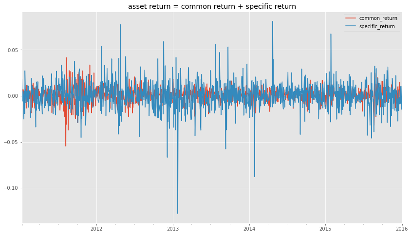

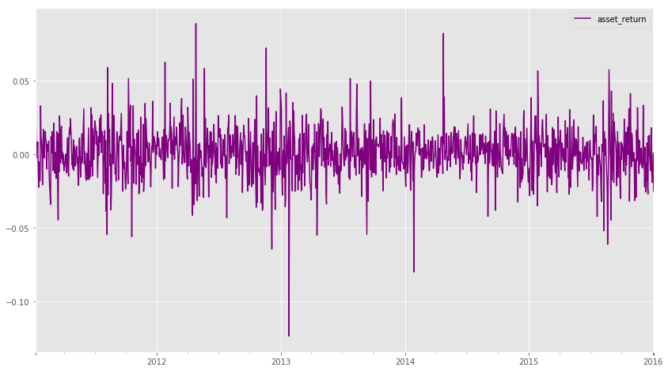

```python
return_components.plot(title="asset return = common return + specific return");
pd.DataFrame(asset_return).plot(color='purple');
```

## Solution

Solution notebook